# Reproducible Research: Peer Assessment 1

## Loading and preprocessing the data

Reading in the code file

```r
activity <- read.csv("/Users/seanmurphy/Desktop/DS_coursera/RepData_PeerAssessment1/activity.csv")
activity$date <- as.Date(activity$date)
# Creating a completely unchanged version of the data for later use
act_demo <- read.csv("/Users/seanmurphy/Desktop/DS_coursera/RepData_PeerAssessment1/activity.csv")
act_demo$date <- as.Date(activity$date)
```

## What is mean total number of steps taken per day?

Calculate the total number of steps taken per day

```r
sum_steps <- aggregate(steps~date, activity, sum)
```

Histogram of the total number of steps taken each day

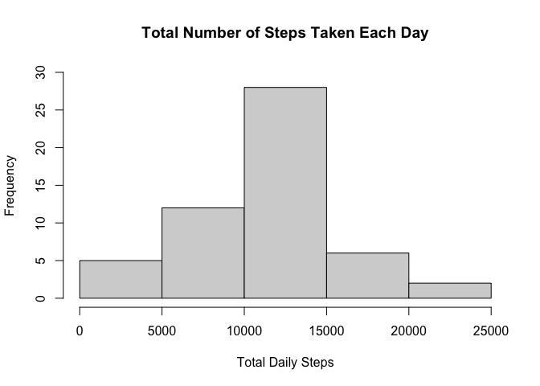

```r
hist(sum_steps$steps, xlab="Total Daily Steps", ylim=c(0,30), main="Total Number of Steps Taken Each Day")
```

Calculate and report the mean steps taken per day

```r
library(dplyr)
activity %>% group_by(date) %>% summarise(mean_steps=mean(steps))
```

```
## # A tibble: 61 × 2
##    date       mean_steps
##    <date>          <dbl>
##  1 2012-10-01     NA
##  2 2012-10-02      0.438
##  3 2012-10-03     39.4
##  4 2012-10-04     42.1
##  5 2012-10-05     46.2
##  6 2012-10-06     53.5
##  7 2012-10-07     38.2
##  8 2012-10-08     NA
##  9 2012-10-09     44.5
## 10 2012-10-10     34.4
## # ℹ 51 more rows
```

and median of the total number of steps taken per day

```r
activity %>% group_by(date) %>% summarise(median_steps=median(steps))
```

```
## # A tibble: 61 × 2
##    date       median_steps
##    <date>            <dbl>
##  1 2012-10-01           NA
##  2 2012-10-02            0
##  3 2012-10-03            0
##  4 2012-10-04            0
##  5 2012-10-05            0
##  6 2012-10-06            0
##  7 2012-10-07            0
##  8 2012-10-08           NA
##  9 2012-10-09            0
## 10 2012-10-10            0
## # ℹ 51 more rows
```

## What is the average daily activity pattern?

Make a time series plot of the 5-minute interval (x-axis) and the average number of steps taken, averaged across all days (y-axis)

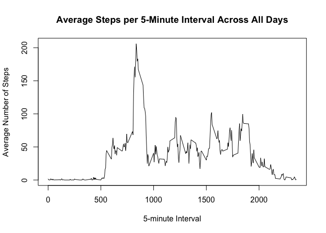

```r
avg_interval_steps <- activity %>%
  group_by(interval) %>%
  summarize(avg_steps = mean(steps, na.rm = TRUE))

plot(avg_interval_steps$interval,
     avg_interval_steps$avg_steps,
     type = "l",
     xlab = "5-minute Interval",
     ylab = "Average Number of Steps",
     main = "Average Steps per 5-Minute Interval Across All Days"
)
```

## Conclusion There is a large spike in step activity between 5-minute interval 750-1000, which likely equates to early-mid morning.

Which 5-minute interval, on average across all the days in the dataset, contains the maximum number of steps?

```r
max_interval_steps <- avg_interval_steps[which.max(avg_interval_steps$avg_steps), "interval"]
max_interval_steps
```

```
## # A tibble: 1 × 1
##   interval
##      <int>
## 1      835
```

## Conclusion

The 835 minute interval contains the maximum number of steps across all the days in the dataset.

## Imputing missing values

Calculate and report the total number of missing values in the dataset (i.e. the total number of rows with NAs)

```r
sum(is.na(activity))
```

```
## [1] 2304
```

Devise a strategy for filling in all of the missing values in the dataset. The strategy does not need to be sophisticated. For example, you could use the mean/median for that day, or the mean for that 5-minute interval, etc.

Used the average steps per interval to fill in NA (missing) values as a solution for this problem.

```r
activity <- activity %>%
  group_by(interval) %>%
  mutate(avg_steps = mean(steps, na.rm = TRUE))
activity$steps <- ifelse(is.na(activity$steps), activity$avg_steps, activity$steps)
sum(is.na(activity$steps))
```

```
## [1] 0
```

New dataset that is equal to the original dataset but with the missing data filled in.

```r
activity$steps <- ifelse(is.na(activity$steps), activity$avg_steps, activity$steps)
activity2 <- data.frame(activity)
activity2$avg_steps <- NULL
class(activity2)
```

```
## [1] "data.frame"
```

Histogram of the total number of steps taken each day and Calculate and report the mean and median total number of steps taken per day.

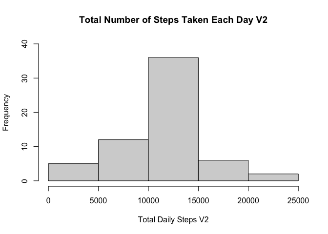

```r
## Histogram
sum_steps2 <- aggregate(steps~date, activity2, sum)
hist(sum_steps2$steps, xlab="Total Daily Steps V2", ylim=c(0,40), main="Total Number of Steps Taken Each Day V2")
```

```r
## Calculating the mean and median steps for new dataframe and old dataframe.
act2_median_steps <- activity2 %>% group_by(date) %>% summarise(median_steps=median(steps))
act2_mean_steps <- activity2 %>% group_by(date) %>% summarise(mean_steps=mean(steps))
act1_median_steps <- activity %>% group_by(date) %>% summarise(median_steps=median(steps))
act1_mean_steps <- activity %>% group_by(date) %>% summarise(mean_steps=mean(steps))

## Calculating the difference in mean steps
act2_mean_steps$mean_steps - act1_mean_steps$mean_steps
```

```
##  [1] 0 0 0 0 0 0 0 0 0 0 0 0 0 0 0 0 0 0 0 0 0 0 0 0 0 0 0 0 0 0 0 0 0 0 0 0 0 0 0 0 0 0 0 0 0 0 0 0 0 0 0 0 0 0 0 0
## [57] 0 0 0 0 0
```

```r
## Calculating the difference in median steps
act2_median_steps$median_steps - act1_median_steps$median_steps
```

```
##  [1] 0 0 0 0 0 0 0 0 0 0 0 0 0 0 0 0 0 0 0 0 0 0 0 0 0 0 0 0 0 0 0 0 0 0 0 0 0 0 0 0 0 0 0 0 0 0 0 0 0 0 0 0 0 0 0 0
## [57] 0 0 0 0 0
```

```r
## Calculating the difference in total steps between the original and new dataset
difference_total_steps <- sum(activity2$steps) -sum(act_demo$steps, na.rm=TRUE)
difference_total_steps
```

```
## [1] 86129.51
```

## Are there differences in activity patterns between weekdays and weekends?

New factor variable in the dataset with two levels – “weekday” and “weekend”.

```r
# Create new column variable
activity2 <- activity2 %>%
  mutate(date = activity$date)

# Change format into days of the week
activity2 <- activity2 %>%
  mutate(day=weekdays(activity$date))

# Change into factor variables to then change into numeric, for easier manipulation
activity2$day <- factor(activity2$day)
activity2$day <- as.numeric(activity2$day)

# Create a list
day2 <- list()

# Loop through column, find weekdays and weekends, add to the new list
for (day in 1:length(activity2$day)) {
  if (activity2$day[[day]] <= 2 | activity2$day[[day]] >= 5) {
    day2[[day]] <- "Weekday"
  }
  else {
    day2[[day]] <- "Weekend"
  }
}

# Swap old column with the new list delineating whether it is a weekend or a weekday
activity2$day <- day2

# Change back into factor variable
activity3 <- as.data.frame(lapply(activity2, unlist))
activity3$day <- factor(activity3$day)
str(activity3$day)
```

```
##  Factor w/ 2 levels "Weekday","Weekend": 1 1 1 1 1 1 1 1 1 1 ...
```

Panel plot containing a time series plot (i.e.type = “l” of the 5-minute interval (x-axis) and the average number of steps taken, averaged across all weekday days or weekend days (y-axis).

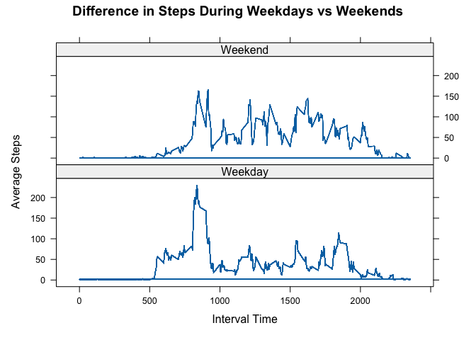

```r
library(lattice)
# Filter the data by day and interval, then find the average steps.
activity3 <- activity3 %>% group_by(day, interval) %>% mutate(mean_steps=mean(steps))

# Plot the subsequent data
xyplot(mean_steps ~ interval | day, data=activity3, type="l", layout=c(1,2),
       ylab="Average Steps", xlab="Interval Time",
       main="Difference in Steps During Weekdays vs Weekends")
```

## Conclusion

From the charts, there seems to be a larger amount of average steps during the start of the day on weekdays, while there is a more constant amount of average steps during weekends.